# 贝叶斯第四章

王珞宇 202222011180

2022-11-04

## **引入**

- 本章将介绍贝叶斯程序的线性回归，并以正态分布（高斯分布）来展现测量的不确定性（$\varepsilon$在线性回归模型中是假定服从正态分布的），因此我们首先来了解正态分布。

## **4.1 为什么正态分布随处可见？**

**4.1.1 通过加法得到正态分布**

1. 假设有一千个人站在足球场的中线，每个人手中都有一枚质地均匀的硬币；
2. 每个人投掷硬币16次。若硬币正面朝上，则向左移动一步；反面朝上则向右移动一步；（这里步长设置为1以内）
3. 投掷16次结束后，测量每个人离中线的距离，得到距离的总分布。

R语言实现如下：

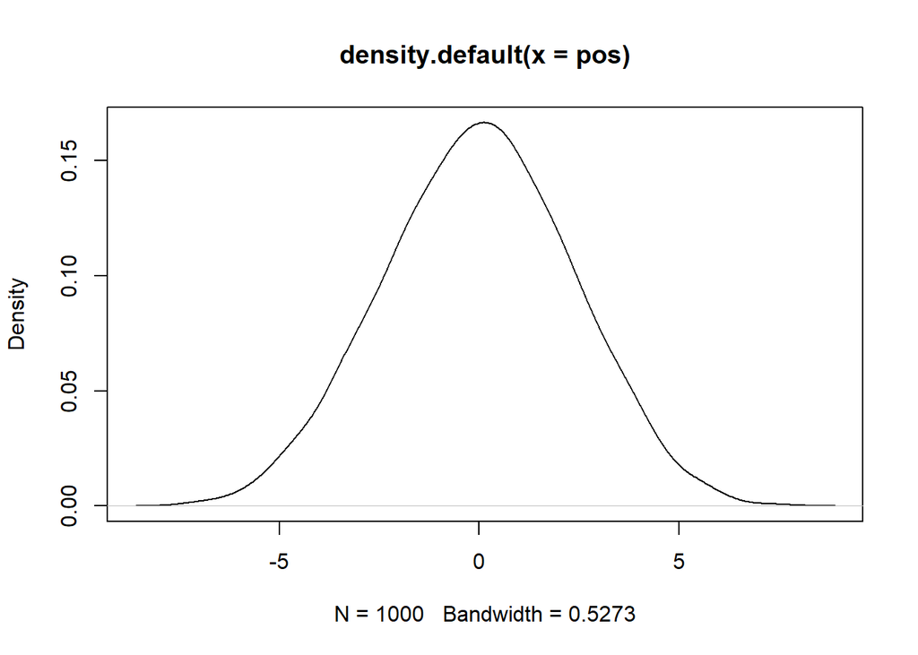

```r
pos <- replicate(1000, sum(runif(16, -1, 1)))
#runif：生成16个（-1，1）均匀分布上的随机数
#sum：求生成16个随机数的和
#replicate：重复sum 1000次

#数据可视化
plot(density(pos)) #绘制密度图
```

随着投掷硬币的次数增多，该分布将越来越接近正态分布。这里我们还需注意到这个实例里面潜在分布是一个投掷硬币的二项分布，最终呈现出的距离分布是正态分布，究竟是什么原因呢？

- 任何将同一分布的随机性相加的过程都会收敛为正态。

  也就是说样本的**随机性之间可以相互抵消**，样本数量越多，这些随机性能被抵消的概率越大，这也是为什么大样本的分布很多时候都趋于正态分布的原因。

  此外，**潜在分布拥有什么形状并不重要**。可以是均匀分布，也可以是其他任何分布。根据潜在分布的不同，收敛（抵消）的速度不同。

**4.1.2 通过相乘得到正态分布**

1. 一个生物体的生长速度受到十几个基因座的影响，每个基因座都有几个等位基因可以编码更多的生长;
2. 所有这些基因组都相互影响，每个都能使生长速度提高一个百分比;
3. 这些基因对生物生长的影响是相乘的，而不是相加。

```r
 prod( 1 + runif(12,0,0.1) )
```

```
## [1] 1.822392
```

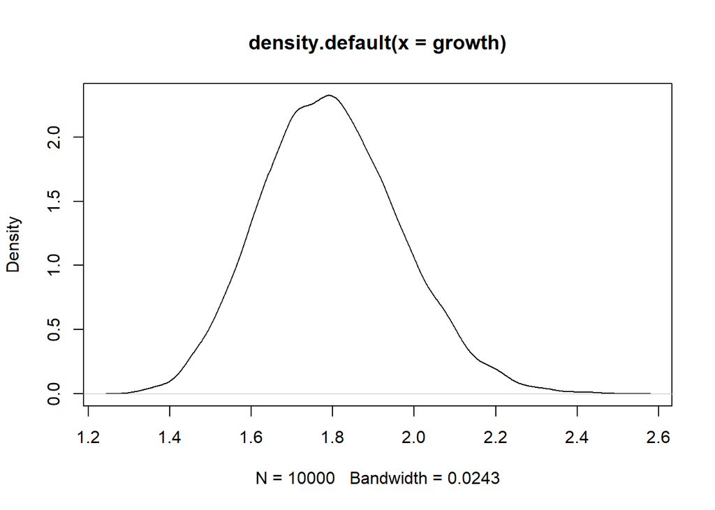

```r
#在1.0和1.1之间随机抽取12个数字，每个数字代表增长的比例。1.0意味着没有额外的增长，1.1意味着10%的 增长。所有12个数字的乘积被计算出来并作为输出返回。
#prod() 函数用于返回其参数中存在的所有值的乘法结果

#生成10000个结果看看是什么分布
growth <- replicate( 10000 , prod( 1 + runif(12,0,0.1) ) )
plot(density(growth))
```

为什么相乘效应也能显示出正态分布呢？

- 小数的乘法作用与加法大致相同。例如，如果有两个位点的等位基因各增加了10%的生长，那么乘积就是
  $$1.1×1.1=1.21=(1+0.1)(1+0.1)=1+0.2+0.01≈1.2$$
  如果小数点后面的数字越小，这种加法近似的效果就越好，因此它们也趋向于稳定在高斯分布上。

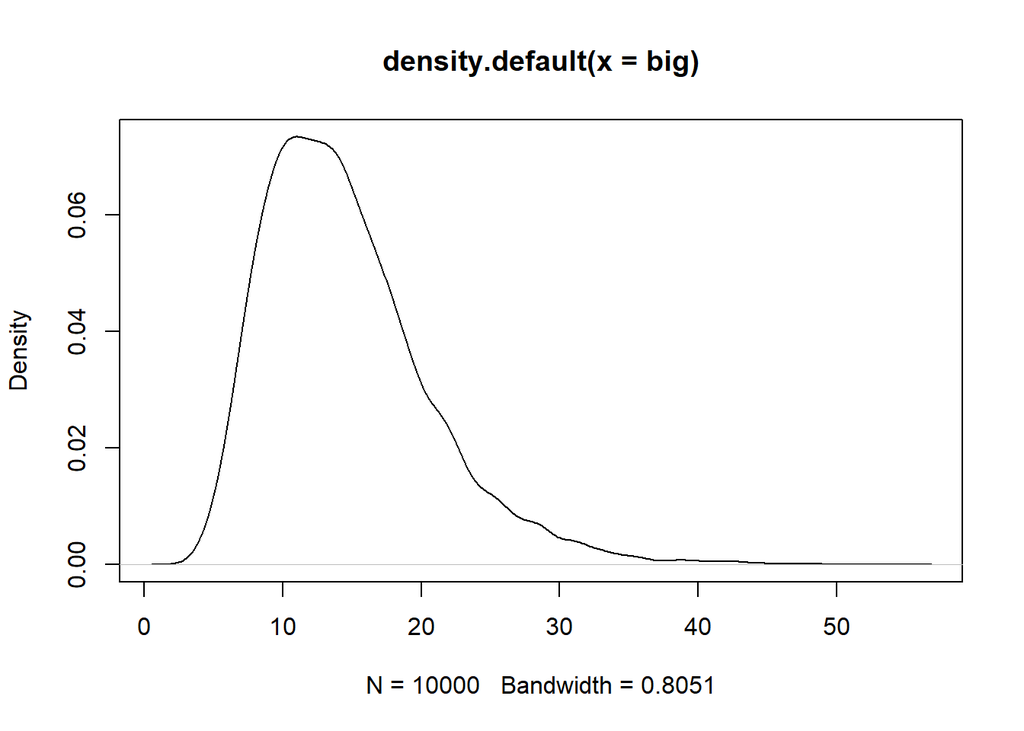

```r
#比较小数点后面数字大小对近似加法作用的影响
big <- replicate( 10000 , prod( 1 + runif(12,0,0.5) ) ) #偏移量0.5
small <- replicate( 10000 , prod( 1 + runif(12,0,0.01) ) ) #偏移量0.1
plot(density(big))
```

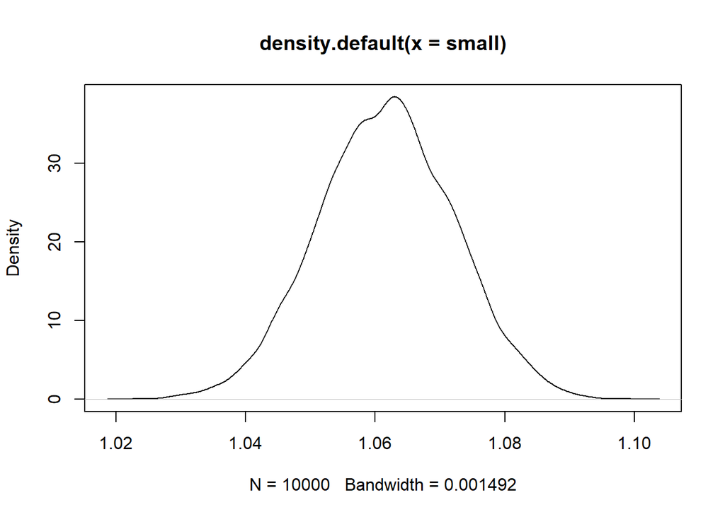

```r
plot(density(small))
```

**4.1.3 通过相乘取对数得到正态分布**

前面说到较大偏离量相乘并不产生高斯分布，但有些倾向于产生对数尺度上的高斯分布。比如：

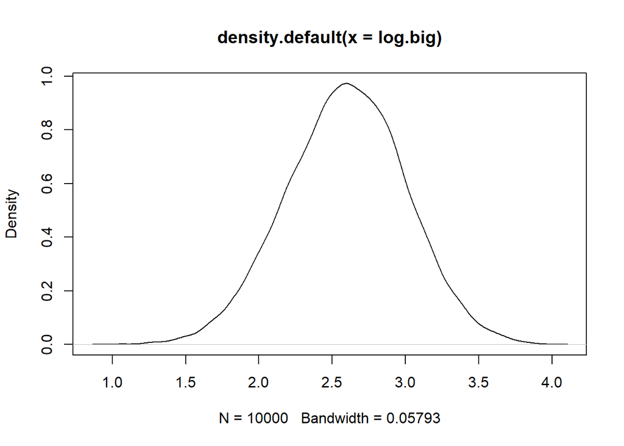

```r
log.big <- replicate( 10000 , log(prod(1 + runif(12,0,0.5)))) #取对数
plot(density(log.big))
```

- 取对数后较大偏差的”相乘”的形式会变成”相加”的形式，从而产生正态分布。

**4.1.4 使用高斯分布**

- 世界上充满了高斯分布，测量误差、增长的变化和分子的运动速度都倾向于高斯分布。之所以如此，是因为他们的核心都是把波动加在一起，使其相互抵消。
- 指数、伽马、泊松分布等一样普遍且常见，高斯分布并不是唯一分布。如果我们对于分布的先验信息只有平均值和方差，或许高斯分布是一个合理的分布推测。

**反思：**厚尾。高斯分布有一些很好的特性，但将其作为默认的数据分布模型也有一些风险：高斯分布的尾部非常细——数据落入其中的概率非常小。但许多自然（和非自然）过程产生极端事件的概率很高。一个真实而重要的例子是金融时间序列——股票市场的涨跌在短期内看起来是高斯的，但在中长期内，极端的冲击使高斯模型并不适用。

**更进一步：**了解高斯分布的概率密度函数
$$p(y|\mu,\sigma)=\frac{1}{\sqrt{2\pi \sigma
^{2}}}exp(-\frac{(y-\mu )^2}{2\sigma ^2})$$

**还有另一种形式**，将$\sigma$替换为$\tau$，这里$\tau=1/\sigma^2$被称为精度，则概率密度函数为
$$p(y|\mu,\sigma)=\sqrt{\frac{\tau }{2\pi
}}exp\left ( -\frac{1}{2} \tau (y-\mu )^2\right )$$

## **4.2 使用简明的语言描述模型**

例如：重新描述投掷地球的模型：
$$W\sim
Binominal(N,p) ; P\sim Uniform(0,1)$$

- 其中W是观察到的水的数量，N是抛掷的总次数，p是地球上水覆盖所占的比例。
- 一旦我们以这种表达方式知道了这个模型，我们就会自然知道它的所有假设。我们知道二项分布假设每个样本（抛球）都是独立于其他样本的，所以我们也知道该模型假设样本点是相互独立的。
- p定义了先验参数。

**更进一步：**从模型定义到贝叶斯定理。为了把上面的数学表达式与贝叶斯定理联系起来，可以用下式来定义后验分布。
$$Pr(p|w,n)=\frac{Binomimal(w|n,p)Uniform(p|0,1)}{\int
Binomial(w|n,p)Uniform(p|0,1)dp}$$

```r
#网格逼近，后验概率的分布
w <- 6; n <- 9;
p_grid <- seq(from=0,to=1,length.out=100)
tmp <- dbinom(w,n,p_grid)
tmp
```

```
##   [1] 0.000000e+00 8.654476e-11 5.371032e-09 5.930670e-08 3.229188e-07
##   [6] 1.193345e-06 3.450793e-06 8.423920e-06 1.816463e-05 3.562420e-05
##  [11] 6.482351e-05 1.110112e-04 1.808039e-04 2.823046e-04 4.251944e-04
##  [16] 6.207946e-04 8.820977e-04 1.223764e-03 1.662083e-03 2.214900e-03
##  [21] 2.901508e-03 3.742503e-03 4.759604e-03 5.975446e-03 7.413338e-03
##  [26] 9.096991e-03 1.105023e-02 1.329666e-02 1.585936e-02 1.876051e-02
##  [31] 2.202102e-02 2.566016e-02 2.969524e-02 3.414114e-02 3.901001e-02
##  [36] 4.431092e-02 5.004944e-02 5.622739e-02 6.284252e-02 6.988821e-02
##  [41] 7.735324e-02 8.522159e-02 9.347228e-02 1.020792e-01 1.110112e-01
##  [46] 1.202317e-01 1.296992e-01 1.393669e-01 1.491834e-01 1.590923e-01
##  [51] 1.690327e-01 1.789399e-01 1.887453e-01 1.983770e-01 2.077603e-01
##  [56] 2.168187e-01 2.254738e-01 2.336466e-01 2.412582e-01 2.482302e-01
##  [61] 2.544860e-01 2.599515e-01 2.645561e-01 2.682337e-01 2.709234e-01
##  [66] 2.725709e-01 2.731291e-01 2.725595e-01 2.708327e-01 2.679297e-01
##  [71] 2.638425e-01 2.585751e-01 2.521441e-01 2.445793e-01 2.359244e-01
##  [76] 2.262371e-01 2.155895e-01 2.040680e-01 1.917733e-01 1.788196e-01
##  [81] 1.653344e-01 1.514573e-01 1.373385e-01 1.231377e-01 1.090215e-01
##  [86] 9.516126e-02 8.173034e-02 6.890041e-02 5.683772e-02 4.569857e-02
##  [91] 3.562420e-02 2.673504e-02 1.912422e-02 1.285032e-02 7.929388e-03
##  [96] 4.325976e-03 1.943362e-03 6.127494e-04 8.145523e-05 0.000000e+00
```

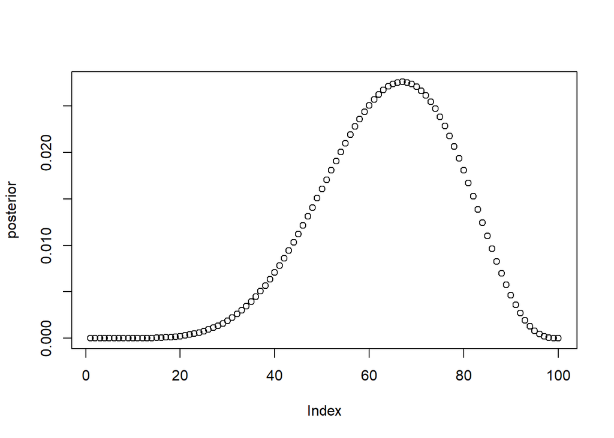

```r
posterior <- dbinom(w,n,p_grid)*dunif(p_grid,0,1)
posterior <- posterior/sum(posterior)
plot(posterior)
```